In [3]:

In [3]:

In [4]: from pyts.visualization import plot_mtf

...:

...:

...: print("Markovian Transition Field-- Images")

...: print("-----------------------------------------------------------")

...: for i in range (0,80):

...: plot_mtf(X_standardized[i], image_size=61, n_bins=4, quantiles='empirical', overlapping=False)

...: print(i)

...: print(train['RunName'][i])

...: print("Drowsy",train['drowsy'][i])

...: print("----------------------------")

Markovian Transition Field-- Images

-----------------------------------------------------------

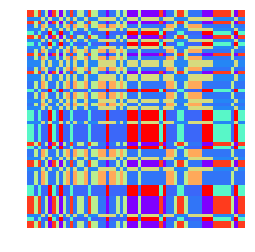

0

A_M1001YM01_3S3RNA

Drowsy True

----------------------------

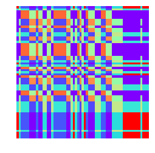

1

A_M1004YM02_3S1RNA

Drowsy True

----------------------------

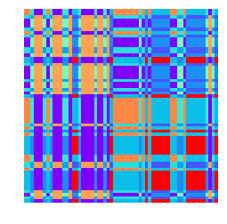

2

A_M1005YM03_1S3RNA

Drowsy True

----------------------------

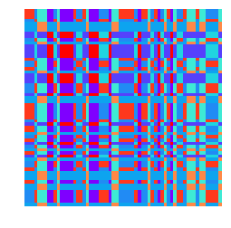

3

A_M1005YM03_3S1RNA

Drowsy True

----------------------------

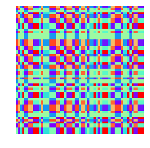

4

A_M1005YM03_3S1RNA

Drowsy True

----------------------------

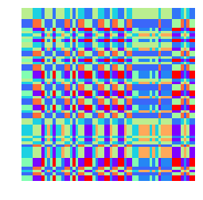

5

A_M1005YM03_3S1RNA

Drowsy True

----------------------------

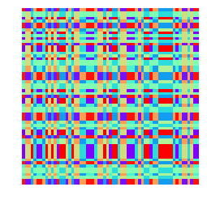

6

A_M1005YM03_3S1RNA

Drowsy True

----------------------------

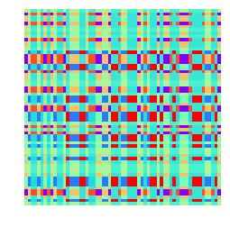

7

A_M1019YF04_1S1RNA

Drowsy True

----------------------------

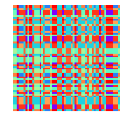

8

A_M1019YF04_2S2RNA

Drowsy True

----------------------------

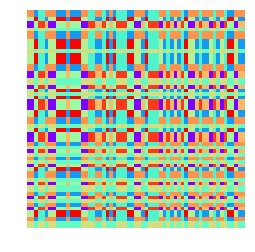

9

A_M1019YF04_2S2RNA

Drowsy True

----------------------------

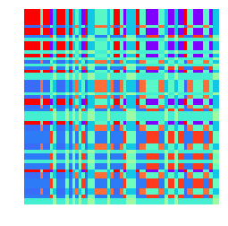

10

A_M1021YF05_2S3RNA

Drowsy True

----------------------------

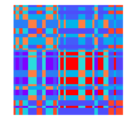

11

A_M1021YF05_2S3RNA

Drowsy True

----------------------------

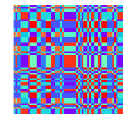

12

A_M1021YF05_2S3RNA

Drowsy True

----------------------------

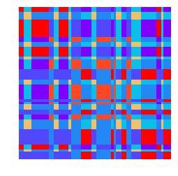

13

A_M1021YF05_2S3RNA

Drowsy True

----------------------------

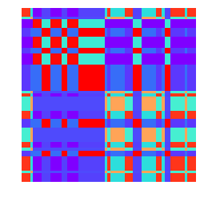

14

A_M1021YF05_3S1RNA

Drowsy True

----------------------------

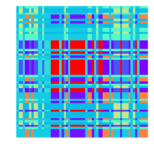

15

A_M1026MM01_3S3RNA

Drowsy True

----------------------------

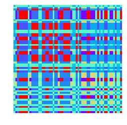

16

A_M1026MM01_3S3RNA

Drowsy True

----------------------------

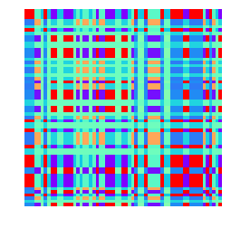

17

A_M1026MM01_3S3RNA

Drowsy True

----------------------------

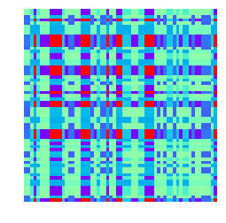

18

A_M1026MM01_3S3RNA

Drowsy True

----------------------------

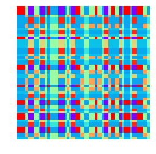

19

A_M1030MM03_3S1RNA

Drowsy True

----------------------------

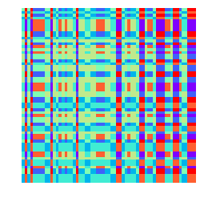

20

A_M1030MM03_3S1RNA

Drowsy True

----------------------------

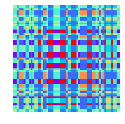

21

A_M1030MM03_3S1RNA

Drowsy True

----------------------------

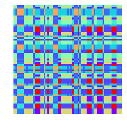

22

A_M1030MM03_3S1RNA

Drowsy True

----------------------------

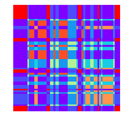

23

A_M1031MM04_2S2RNA

Drowsy True

----------------------------

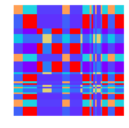

24

A_M1038MF01_1S1RNA

Drowsy True

----------------------------

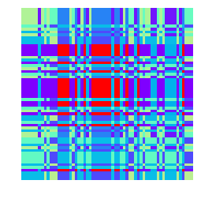

25

A_M1038MF01_1S1RNA

Drowsy True

----------------------------

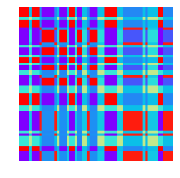

26

A_M1038MF01_1S1RNA

Drowsy True

----------------------------

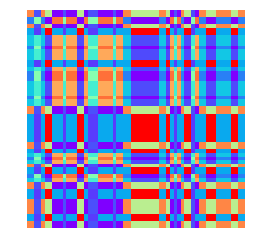

27

A_M1038MF01_2S2RNA

Drowsy True

----------------------------

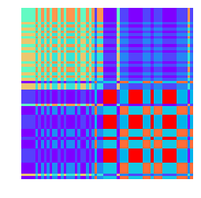

28

A_M1038MF01_2S2RNA

Drowsy True

----------------------------

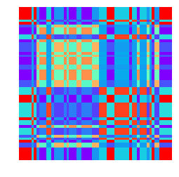

29

A_M1038MF01_2S2RNA

Drowsy True

----------------------------

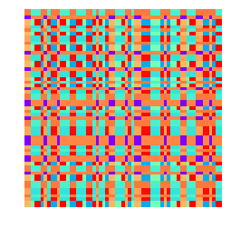

30

A_M1038MF01_3S3RNA

Drowsy True

----------------------------

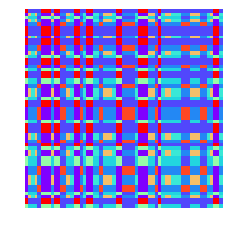

31

A_M1038MF01_3S3RNA

Drowsy True

----------------------------

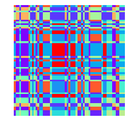

32

A_M1038MF01_3S3RNA

Drowsy True

----------------------------

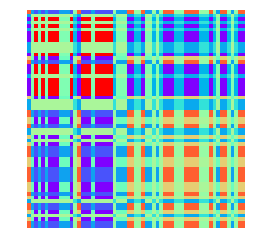

33

A_M1038MF01_3S3RNA